# Problem set #8: tree-based methods and support vector machines

Bobae Kang

March 6, 2017

# Part 1: Sexy Joe Biden (redux times two) [3 points]

In this part, I use and compare a variety of tree-based models on the `biden.csv` data. In doing so, I use the cross-validation approach, splitting the original data randomly into a training set (70% of all observations) and a test/validation set (30% of all observations).

## Fit a decision tree

Fist, I grow a decision tree using the training data. `biden` is the response variable and other variables are predictors. I have set seed to be 0 for reproducibility. Without any input for control argument, the algorithm chose a model with three terminal nodes. The model predicts that, if an observation is democrat, the themometer score is 74.49. For observations that are not not democrat, the model predicts that the themometer score is 44.17 if an observation is republican and 57.42 otherwise. Its mean squared error (MSE) on the test set is 387.9136.

```
##
## Regression tree:
## tree(formula = biden ~ ., data = biden_train)
## Variables actually used in tree construction:
## [1] "dem" "rep"
## Number of terminal nodes:  3
## Residual mean deviance:  408.6 = 515600 / 1262
## Distribution of residuals:
##    Min. 1st Qu.  Median    Mean 3rd Qu.    Max.
## -74.490 -14.170   2.581   0.000  12.580  50.830
```

```
## [1] "Test MSE:"
```

```
## [1] 387.9136
```

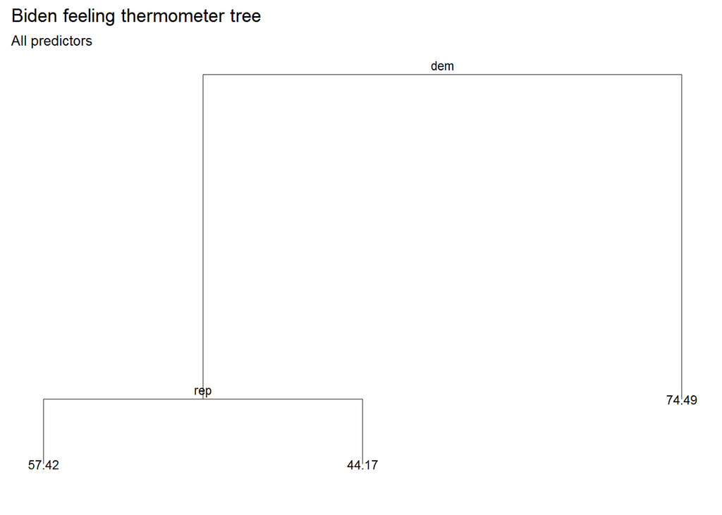

## Fit another decision tree

What if I let the model to grow more branches? In this second tree with different `control` options, there are 196 terminal nodes. Again, being democrat is responsible for the first split as in the previous tree. However, in the plot, it is difficult to identify what the predictios are at terminal nodes. The MSE is 528.6294, which is significantly larger than the MSE of the previous tree. More splits seemingly lead to worse performance.

```
##
## Regression tree:
## tree(formula = biden ~ ., data = biden_train, control = tree.control(nobs = nrow(biden_train),
##     mindev = 0))
## Number of terminal nodes:  196
## Residual mean deviance:  344.4 = 368200 / 1069
## Distribution of residuals:
##     Min.  1st Qu.   Median     Mean  3rd Qu.     Max.
## -60.0000 -10.0000  -0.5556   0.0000  12.0000  47.8600
```

```
## [1] "Test MSE:"
```

```
## [1] 528.6294
```

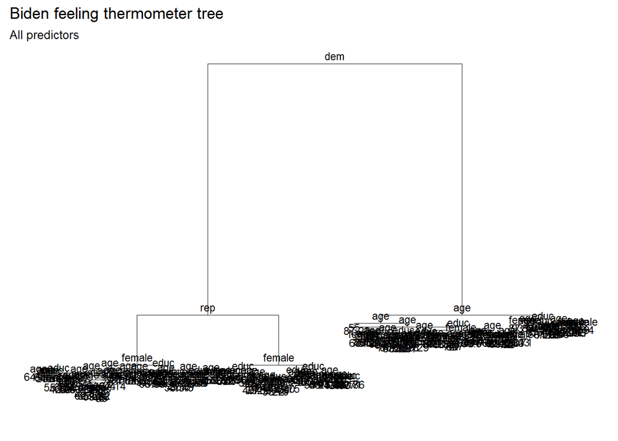

## Cross-validation

To find out the optimal number of terminal nodes, I try the 10-fold cross-validation approach. The plot illustrates the MSE values for different number of terminal nodes. We find that a tree with three terminal nodes has the least MSE value. This is the first tree I fitted above! The MSE score then increases with more terminal nodes.

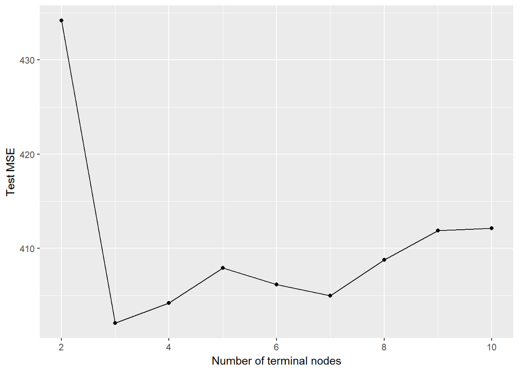

## Bagging

```
##
## Call:
##  randomForest(formula = biden ~ ., data = biden_test, mtry = 5,      ntree = 5000)
##                Type of random forest: regression
##                      Number of trees: 5000
## No. of variables tried at each split: 5
##
##           Mean of squared residuals: 480.431
##                     % Var explained: 13.32
```

```
## [1] "Test MSE:"
```

```
## [1] 143.7562
```

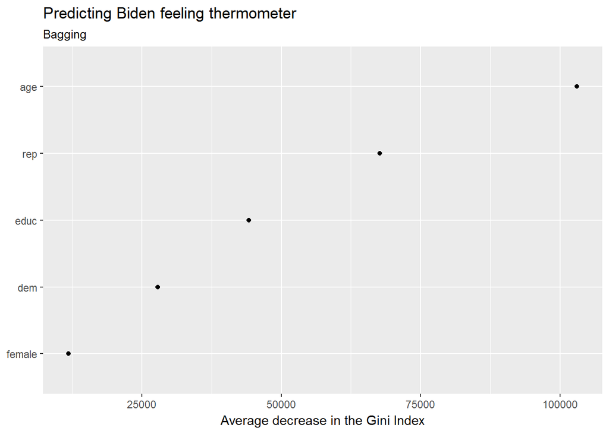

## Random Forest

```
##
## Call:
##  randomForest(formula = biden ~ ., data = biden_test, ntree = 5000)
##                Type of random forest: regression
##                      Number of trees: 5000
## No. of variables tried at each split: 1
##
##           Mean of squared residuals: 394.3393
##                     % Var explained: 28.86
```

```
## [1] "Test MSE:"
```

```
## [1] 357.0435
```

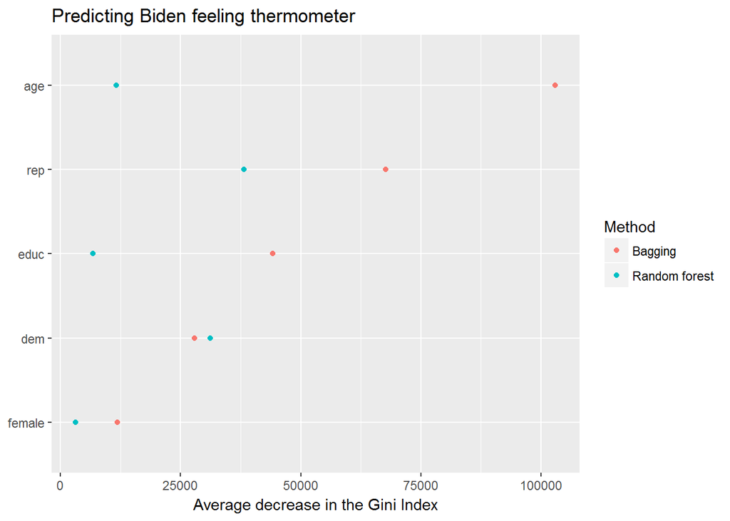

## Boosting

```
## Distribution not specified, assuming gaussian ...
## Distribution not specified, assuming gaussian ...
## Distribution not specified, assuming gaussian ...
```

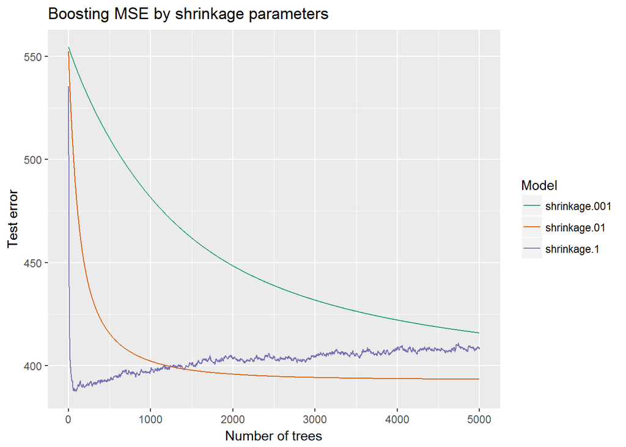